# Ridge and Lasso Regression

In this notebook, we will use the Credit dataset from ISLR2 package to estimate Ridge and LASSO regression models. The dataset includes information on Income, Limit, Rating, Student status etc. along with the average credit card balance in dollars.

We will use the gmlnet() package to automatically standardize the predictors. Load the libraries

```r
library(data.table)
library(ISLR2)
library(tidyverse)
library(caret)
library(glmnet)
```

Load the dataset

```r
dt <- data.table(ISLR2::Credit)[, !c("ID")]
head(dt)
```

| Income | Limit | Rating | Cards | Age | Education | Own | Student | Married | Region | Balance |
| --- | --- | --- | --- | --- | --- | --- | --- | --- | --- | --- |
| 14.891 | 3606 | 283 | 2 | 34 | 11 | No | No | Yes | South | 333 |
| 106.025 | 6645 | 483 | 3 | 82 | 15 | Yes | Yes | Yes | West | 903 |
| 104.593 | 7075 | 514 | 4 | 71 | 11 | No | No | No | West | 580 |
| 148.924 | 9504 | 681 | 3 | 36 | 11 | Yes | No | No | West | 964 |
| 55.882 | 4897 | 357 | 2 | 68 | 16 | No | No | Yes | South | 331 |
| 80.180 | 8047 | 569 | 4 | 77 | 10 | No | No | No | South | 1151 |

The first column is an identifier and not a predictor. It needs to be removed.

Create training/testing datasets by setting seed

```r
set.seed(123)

rowPicker <- sample(c(TRUE, FALSE), nrow(dt), replace = TRUE, prob = c(.8, .2))

train_data <- dt[rowPicker]
test_data <- dt[!rowPicker]
```

```r
# 80% of dataset is used for training
```

create the training and testing datasets

```r
# generate test data from rows not included in train_data
```

Set up the train control for 10-fold cross validation

```r
# First define the traincontrol to specify k-fold
train_control <- trainControl(method ="cv", number = 10)
```

Before we estimate the ridge and lasso models, we need consider a range of values for the regularization parameter $\lambda$. We will consider values between 0.01 and 10^5.

```r
lambda <- 10^seq(-2, 5, length = 100)
```

## Ridge Regression

```r
model_ridge <- train(Balance ~ ., data = train_data, method = "glmnet",
                     trControl = train_control,
                     tuneGrid = expand.grid(alpha = 0, lambda = lambda))
summary(model_ridge)
```

```
            Length Class      Mode
a0           100   -none-     numeric
beta        1100   dgCMatrix  S4
df           100   -none-     numeric
dim            2   -none-     numeric
lambda       100   -none-     numeric
dev.ratio    100   -none-     numeric
nulldev        1   -none-     numeric
npasses        1   -none-     numeric
jerr           1   -none-     numeric
offset         1   -none-     logical
call           5   -none-     call
nobs           1   -none-     numeric
lambdaOpt      1   -none-     numeric
xNames        11   -none-     character
problemType    1   -none-     character
tuneValue      2   data.frame list
obsLevels      1   -none-     logical
param          0   -none-     list
```

Obtain model coefficients

```r
coef(model_ridge$finalModel, model_ridge$bestTune$lambda)
```

```
12 x 1 sparse Matrix of class "dgCMatrix"
                      s1
(Intercept) -397.8348601
Income        -5.5108770
Limit          0.1157509
Rating         1.6745196
Cards         12.5990787
Age           -0.8888508
Education      0.1297232
OwnYes        -6.9871558
StudentYes   401.0818134
MarriedYes    -6.7643539
RegionSouth    3.6335301
RegionWest    10.7455143
```

Make predictions

```r
prediction_ridge <- predict(model_ridge, newdata = test_data)
```

Check model performance

```r
c("R_Square" = R2(prediction_ridge, test_data$Balance),
  "RMSE" = RMSE(prediction_ridge, test_data$Balance),
  "MAE" = MAE(prediction_ridge, test_data$Balance))
```

```
   R_Square        RMSE         MAE
  0.9621475 108.4114419  94.0123318
```

## Lasso Regression

same code as Ridge except the alpha is changed to 1

```r
model_lasso <- train(Balance ~ ., data = train_data, method = "glmnet",
                     trControl = train_control,
                     tuneGrid = expand.grid(alpha = 1, lambda = lambda))
summary(model_lasso)
```

```
            Length Class      Mode
a0           70    -none-     numeric
beta        770    dgCMatrix  S4
df           70    -none-     numeric
dim           2    -none-     numeric
lambda       70    -none-     numeric
dev.ratio    70    -none-     numeric
nulldev       1    -none-     numeric
npasses       1    -none-     numeric
jerr          1    -none-     numeric
offset        1    -none-     logical
call          5    -none-     call
nobs          1    -none-     numeric
lambdaOpt     1    -none-     numeric
xNames       11    -none-     character
problemType   1    -none-     character
tuneValue     2    data.frame list
obsLevels     1    -none-     logical
param         0    -none-     list
```

Obtain model coefficients

```r
coef(model_lasso$finalModel, model_lasso$bestTune$lambda)
```

```
12 x 1 sparse Matrix of class "dgCMatrix"
                      s1
(Intercept) -468.5146210
Income        -7.6686616
Limit          0.1661664
Rating         1.4180109
Cards         13.4029412
Age           -0.5478482
Education      .
OwnYes        -9.4262999
StudentYes   430.9666137
MarriedYes    -3.8756927
RegionSouth    .
RegionWest     8.5178585
```

Make predictions

```r
prediction_lasso <- predict(model_lasso, newdata = test_data)
```

Check model performance

```r
c("R_Square" = R2(prediction_lasso, test_data$Balance),
  "RMSE" = RMSE(prediction_lasso, test_data$Balance),
  "MAE" = MAE(prediction_lasso, test_data$Balance))
```

```
  R_Square       RMSE        MAE
 0.9681169 93.2736028 78.7039433
```

## Linear Model

```r
model_linear <- train(Balance ~ ., data = train_data,
                     method = "lm",
                     metric = "Rsquared")
coef(model_linear$finalModel)
```

```
 (Intercept)       Income        Limit       Rating        Cards          Age    Education       OwnYes   StudentYes
-463.6166806   -7.8598971    0.1839005    1.2000272   15.7101907   -0.6145450   -0.4995049  -12.6776523  436.0110604
  MarriedYes  RegionSouth   RegionWest
  -7.3906066    4.6069803   15.9974269
```

Make predictions

```r
prediction_linear <- predict(model_linear, newdata = test_data)
```

Create a dataframe to compare coefficients of the three models

```r
data.frame(
  ridge = as.data.frame.matrix(coef(model_ridge$finalModel, model_ridge$finalModel$lambdaOpt)),
  lasso = as.data.frame.matrix(coef(model_lasso$finalModel, model_lasso$finalModel$lambdaOpt)),
  linear = (model_linear$finalModel$coefficients)
)
```

|  | s1 | s1.1 | linear |
| --- | --- | --- | --- |
| (Intercept) | -397.8348601 | -468.5146210 | -463.6166806 |
| Income | -5.5108770 | -7.6686616 | -7.8598971 |
| Limit | 0.1157509 | 0.1661664 | 0.1839005 |
| Rating | 1.6745196 | 1.4180109 | 1.2000272 |
| Cards | 12.5990787 | 13.4029412 | 15.7101907 |
| Age | -0.8888508 | -0.5478482 | -0.6145450 |
| Education | 0.1297232 | 0.0000000 | -0.4995049 |
| OwnYes | -6.9871558 | -9.4262999 | -12.6776523 |
| StudentYes | 401.0818134 | 430.9666137 | 436.0110604 |
| MarriedYes | -6.7643539 | -3.8756927 | -7.3906066 |

[output cut: 2 more lines]

Rename the first two columns to ridge and lasso

```r
data.frame(
  ridge = as.data.frame.matrix(coef(model_ridge$finalModel, model_ridge$finalModel$lambdaOpt)),
  lasso = as.data.frame.matrix(coef(model_lasso$finalModel, model_lasso$finalModel$lambdaOpt)),
  linear = (model_linear$finalModel$coefficients)
) %>%
rename(ridge = s1, lasso = s1.1)
```

|  | ridge | lasso | linear |
| --- | --- | --- | --- |
| (Intercept) | -397.8348601 | -468.5146210 | -463.6166806 |
| Income | -5.5108770 | -7.6686616 | -7.8598971 |
| Limit | 0.1157509 | 0.1661664 | 0.1839005 |
| Rating | 1.6745196 | 1.4180109 | 1.2000272 |
| Cards | 12.5990787 | 13.4029412 | 15.7101907 |
| Age | -0.8888508 | -0.5478482 | -0.6145450 |
| Education | 0.1297232 | 0.0000000 | -0.4995049 |
| OwnYes | -6.9871558 | -9.4262999 | -12.6776523 |
| StudentYes | 401.0818134 | 430.9666137 | 436.0110604 |
| MarriedYes | -6.7643539 | -3.8756927 | -7.3906066 |

[output cut: 2 more lines]

Create a dataframe to compare the model performance of the three models

```r
c("Ridge_Rsq" = R2(prediction_ridge, test_data$Balance),
  "Lasso_Rsq" = R2(prediction_lasso, test_data$Balance),
  "Linear_Rsq" = R2(prediction_linear, test_data$Balance))
```

```
 Ridge_Rsq  Lasso_Rsq Linear_Rsq
 0.9621475  0.9681169  0.9679819
```

## Plot the coefficients of model objects

We can use the coefplot package and the function coefpath() to plot the coefficients of ridge and lasso models.

Install the coefplot package in the console before running the following code

```r
library(coefplot)
```

Path plot for ridge regression

```r
coefpath(model_ridge$finalModel)
```

[interactive chart not shown]

Regular Plot for comparison

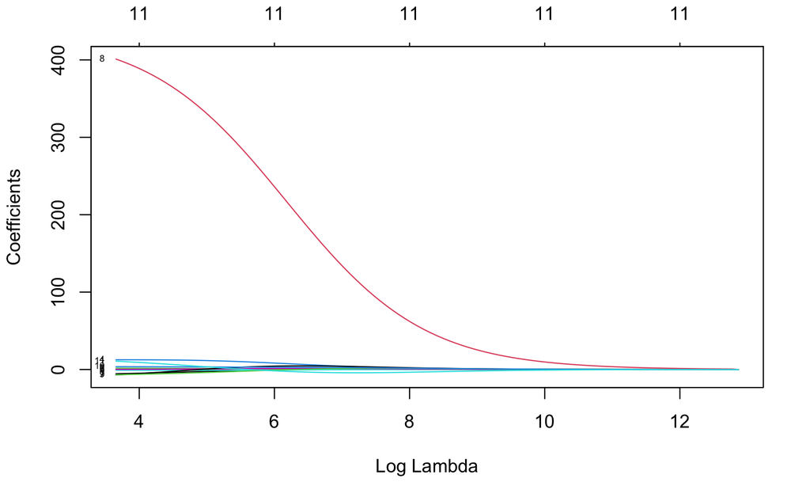

```r
plot(model_ridge$finalModel, xvar = "lambda", label = T)
```

A similar plot can be done for the LASSO model